# Analyse 3 - Sante, Morbidite et Acces aux Soins des menages nigerians

Ahmed Firhoun OUMAROU SOULEYE & Gerald Guerngue ADDJITA

2026-03-12

```r
library(haven)
library(dplyr)
```

```r
library(ggplot2)
library(forcats)
library(tidyr)
library(scales)
library(viridis)
library(gtsummary)

processed_sante_w4 <- read_dta("../data/processed/processed_sante_w4.dta")
```

```r
processed_sante_w4 <- processed_sante_w4 %>%
  mutate(
    zone_label = factor(sector, levels = c(1, 2),
                        labels = c("Rural", "Urbain")),
    sexe_label = factor(s1q2,   levels = c(1, 2),
                        labels = c("Homme", "Femme"))
  )
```

### 13. Charger sect4a_harvestw4, le joindre a sect1_harvestw4 et totcons_final. Explorer la structure, verifier les doublons et les valeurs manquantes. Calculer le taux de morbidite global et par sexe et groupe d’age.

#### 13.a. Dimensions et structure

```r
cat("Dimensions processed_sante_w4 :",
    nrow(processed_sante_w4), "individus x",
    ncol(processed_sante_w4), "variables\n")
```

```
## Dimensions processed_sante_w4 : 26556 individus x 25 variables
```

```r
glimpse(processed_sante_w4)
```

```
## Rows: 26,556
## Columns: 25
## $ hhid                 <dbl> 10001, 10001, 10001, 10001, 10001, 10001, 10002, …
## $ indiv                <dbl> 1, 2, 3, 4, 8, 9, 1, 2, 3, 8, 9, 1, 2, 3, 4, 5, 6…
## $ sante_s4aq1          <dbl+lbl> 2, 2, 2, 2, 2, 2, 2, 2, 2, 2, 2, 2, 2, 2, 2, …
## $ sante_s4aq3          <dbl+lbl>  2,  2,  2,  2,  2,  2,  2,  1,  2,  1,  2,  …
## $ sante_s4aq3b_1       <dbl+lbl> NA, NA, NA, NA, NA, NA, NA, 16, NA, 10, NA, N…
## $ sante_s4aq5          <dbl> NA, NA, NA, NA, NA, NA, NA, NA, NA, NA, NA, NA, N…
## $ sante_s4aq6a         <dbl+lbl> NA, NA, NA, NA, NA, NA, NA,  1, NA,  1, NA, N…
## $ sante_s4aq9          <dbl+lbl> NA, NA, NA, NA, NA, NA, NA, NA, NA, NA, NA, N…
## $ sante_s4aq10         <dbl+lbl>  NA,  NA,  NA,  NA,  NA,  NA,  NA,  NA,  NA, …
## $ sante_s4aq14         <dbl> NA, NA, NA, NA, NA, NA, NA, 350, NA, 400, NA, NA,…
## $ sante_s4aq15         <dbl+lbl> 2, 2, 2, 2, 2, 2, 2, 2, 2, 2, 2, 2, 2, 2, 2, …
## $ s1q2                 <dbl+lbl> 1, 2, 2, 2, 1, 1, 1, 2, 1, 2, 2, 1, 2, 1, 2, …
## $ s1q4                 <dbl> 55, 41, 11, 53, 8, 2, 52, 45, 17, 8, 6, 60, 49, 2…
## $ sector               <dbl+lbl> 1, 1, 1, 1, 1, 1, 1, 1, 1, 1, 1, 1, 1, 1, 1, …
## $ state                <dbl+lbl> 1, 1, 1, 1, 1, 1, 1, 1, 1, 1, 1, 1, 1, 1, 1, …
## $ zone                 <dbl+lbl> 4, 4, 4, 4, 4, 4, 4, 4, 4, 4, 4, 4, 4, 4, 4, …
## $ lga                  <dbl+lbl> 15, 15, 15, 15, 15, 15, 15, 15, 15, 15, 15, 1…
## $ totcons_adj          <dbl> 257109.7, 257109.7, 257109.7, 257109.7, 257109.7,…
## $ totcons_pc           <dbl> 271636.5, 271636.5, 271636.5, 271636.5, 271636.5,…
## $ hhsize               <dbl> 6, 6, 6, 6, 6, 6, 5, 5, 5, 5, 5, 6, 6, 6, 6, 6, 6…
## $ quintile_cons        <dbl> 4, 4, 4, 4, 4, 4, 5, 5, 5, 5, 5, 5, 5, 5, 5, 5, 5…
## $ quintile_label       <dbl+lbl> 4, 4, 4, 4, 4, 4, 5, 5, 5, 5, 5, 5, 5, 5, 5, …
## $ sante_depense_totale <dbl> NA, NA, NA, NA, NA, NA, NA, 350, NA, 400, NA, NA,…
## $ zone_label           <fct> Rural, Rural, Rural, Rural, Rural, Rural, Rural, …
## $ sexe_label           <fct> Homme, Femme, Femme, Femme, Homme, Homme, Homme, …
```

#### 13.b. Verifier les doublons

```r
nrow(unique(processed_sante_w4[, c("hhid", "indiv")]))
```

```
## [1] 26556
```

```r
nrow(processed_sante_w4)
```

```
## [1] 26556
```

La cle composite hhid+indiv est unique, aucun doublon n’est presente dans la base.

#### 13.c. Valeurs manquantes

```r
vars_cles <- c("sante_s4aq3","sante_s4aq1","sante_s4aq6a",
               "sante_s4aq9","sante_s4aq14","sante_s4aq15")
miss_sante <- processed_sante_w4 %>%
  select(any_of(vars_cles)) %>%
  summarise(across(everything(), ~ sum(is.na(.)))) %>%
  pivot_longer(everything(),
               names_to  = "Variable",
               values_to = "N_manquants") %>%
  mutate(Pct = round(N_manquants / nrow(processed_sante_w4) * 100, 1))
print(miss_sante)
```

```
## # A tibble: 6 × 3
##   Variable     N_manquants   Pct
##   <chr>              <int> <dbl>
## 1 sante_s4aq3         4385  16.5
## 2 sante_s4aq1            0   0
## 3 sante_s4aq6a       20106  75.7
## 4 sante_s4aq9        21018  79.1
## 5 sante_s4aq14       18632  70.2
## 6 sante_s4aq15           0   0
```

```r
visdat::vis_miss(
  select(processed_sante_w4, any_of(vars_cles))
)
```

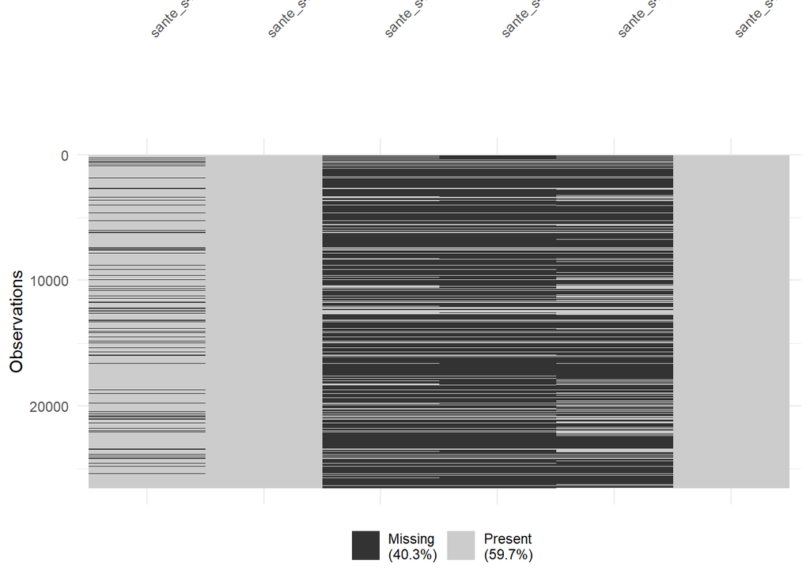

#### 13.d. Taux de morbidite global

```r
morb_d <- processed_sante_w4 %>%
  filter(!is.na(sante_s4aq3), !is.na(s1q4), !is.na(s1q2)) %>%
  mutate(
    gr_age = cut(s1q4,
      breaks = c(0, 5, 15, 30, 45, 60, Inf),
      labels = c("0-4 ans","5-14 ans","15-29 ans",
                 "30-44 ans","45-59 ans","60+ ans"),
      right  = FALSE)
  ) %>%
  filter(!is.na(gr_age))

taux_g <- morb_d %>%
  summarise(
    N     = n(),
    n_mal = sum(sante_s4aq3 == 1, na.rm = TRUE),
    taux  = round(n_mal / N * 100, 1)
  )
cat("Taux de morbidite global :", taux_g$taux, "%\n")
```

```
## Taux de morbidite global : 9.3 %
```

```r
cat("N individus analyses :", taux_g$N, "\n")
```

```
## N individus analyses : 22171
```

#### 13.e. Taux par sexe et groupe d’age

```r
taux_morb <- morb_d %>%
  group_by(sexe_label, gr_age) %>%
  summarise(
    N      = n(),
    n_mal  = sum(sante_s4aq3 == 1, na.rm = TRUE),
    Taux   = round(n_mal / N * 100, 1),
    IC_inf = round(binom.test(n_mal, N)$conf.int[1] * 100, 1),
    IC_sup = round(binom.test(n_mal, N)$conf.int[2] * 100, 1),
    .groups = "drop"
  )
print(taux_morb)
```

```
## # A tibble: 12 × 7
##    sexe_label gr_age        N n_mal  Taux IC_inf IC_sup
##    <fct>      <fct>     <int> <int> <dbl>  <dbl>  <dbl>
##  1 Homme      0-4 ans    1267   154  12.2   10.4   14.1
##  2 Homme      5-14 ans   3691   204   5.5    4.8    6.3
##  3 Homme      15-29 ans  2984   190   6.4    5.5    7.3
##  4 Homme      30-44 ans  1488   128   8.6    7.2   10.1
##  5 Homme      45-59 ans  1051   119  11.3    9.5   13.4
##  6 Homme      60+ ans     653   135  20.7   17.6   24
##  7 Femme      0-4 ans    1294   141  10.9    9.3   12.7
##  8 Femme      5-14 ans   3428   232   6.8    5.9    7.7
##  9 Femme      15-29 ans  2732   225   8.2    7.2    9.3
## 10 Femme      30-44 ans  1901   204  10.7    9.4   12.2
## 11 Femme      45-59 ans  1041   166  15.9   13.8   18.3
## 12 Femme      60+ ans     641   167  26.1   22.7   29.6
```

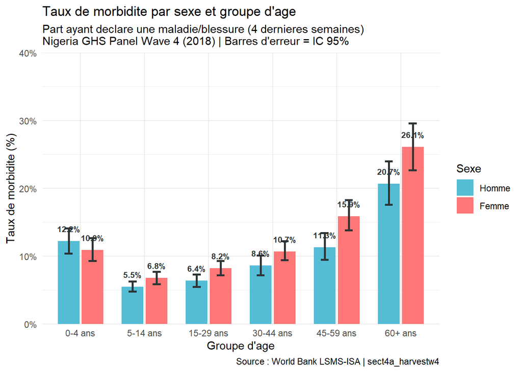

```r
ggplot(taux_morb,
  aes(x = gr_age, y = Taux,
      fill = sexe_label, group = sexe_label)) +
  geom_col(position = position_dodge(width = 0.75),
           width = 0.68, alpha = 0.92) +
  geom_errorbar(
    aes(ymin = IC_inf, ymax = IC_sup),
    position = position_dodge(width = 0.75),
    width = 0.25, linewidth = 0.9, color = "#2D3436"
  ) +
  geom_text(
    aes(label = paste0(Taux, "%")),
    position = position_dodge(width = 0.75),
    vjust = -1.5, size = 2.8,
    fontface = "bold", color = "#2D3436"
  ) +
  scale_fill_manual(
    values = c("Homme" = "#45B7D1", "Femme" = "#FF6B6B"),
    name   = "Sexe"
  ) +
  scale_y_continuous(
    labels = function(x) paste0(x, "%"),
    limits = c(0, 40), expand = c(0, 0)
  ) +
  labs(
    title    = "Taux de morbidite par sexe et groupe d'age",
    subtitle = paste0(
      "Part ayant declare une maladie/blessure (4 dernieres semaines)\n",
      "Nigeria GHS Panel Wave 4 (2018) | Barres d'erreur = IC 95%"),
    x = "Groupe d'age", y = "Taux de morbidite (%)",
    caption = "Source : World Bank LSMS-ISA | sect4a_harvestw4"
  ) +
  theme_minimal()
```

### 14. Identifier les principales affections declarees par les individus malades. Classer le top 10 et visualiser par categorie (infectieuse, traumatique, chronique, autre).

#### 14.a. Frequences des affections

```r
maladies_d <- processed_sante_w4 %>%
  filter(!is.na(sante_s4aq3b_1), sante_s4aq3 == 1) %>%
  mutate(
    maladie_label = as_factor(sante_s4aq3b_1),
    categorie = case_when(
      as.integer(sante_s4aq3b_1) %in% 1:7  ~ "Infectieuse",
      as.integer(sante_s4aq3b_1) %in% 8:10 ~ "Traumatique",
      as.integer(sante_s4aq3b_1) %in% 11:15~ "Chronique",
      TRUE ~ "Autre"
    )
  )

freq_mal <- maladies_d %>%
  count(maladie_label, categorie, name = "n") %>%
  mutate(prop = round(n / sum(n) * 100, 1)) %>%
  arrange(desc(n)) %>%
  slice_head(n = 10) %>%
  mutate(maladie_label = fct_reorder(maladie_label, n))

print(select(as.data.frame(freq_mal),
             maladie_label, categorie, n, prop))
```

```
##             maladie_label   categorie   n prop
## 1          27. BODY PAINS       Autre 518 25.1
## 2              1. MALARIA Infectieuse 514 24.9
## 3             15. CATARRH   Chronique 244 11.8
## 4            17. HEADACHE       Autre 195  9.4
## 5               16. COUGH       Autre 182  8.8
## 6         10. COMMON COLD Traumatique  71  3.4
## 7  24. ULCER/STOMACH PAIN       Autre  70  3.4
## 8              11. INJURY   Chronique  58  2.8
## 9      12. OTHER(SPECIFY)   Chronique  36  1.7
## 10        25. EYE PROBLEM       Autre  27  1.3
```

#### 14.b. Barplot par categorie

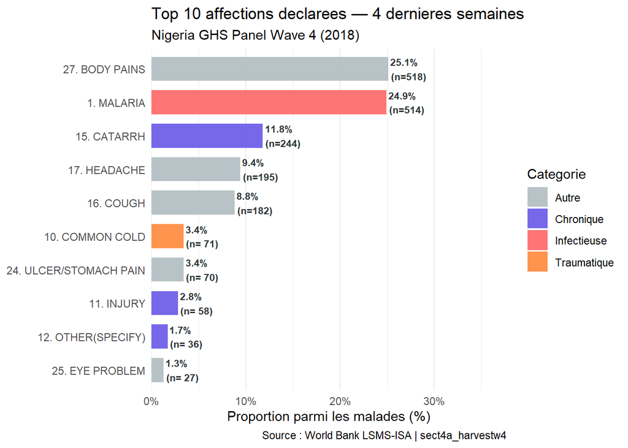

```r
pal_categorie <- c(
  "Infectieuse" = "#FF6B6B", "Traumatique" = "#FF8C42",
  "Chronique"   = "#6C5CE7", "Autre"       = "#B2BEC3"
)

ggplot(freq_mal,
  aes(x = maladie_label, y = prop, fill = categorie)) +
  geom_col(width = 0.72, alpha = 0.93) +
  geom_text(
    aes(label = paste0(prop, "%\n(n=",
                       format(n, big.mark = " "), ")")),
    hjust = -0.08, size = 2.8,
    fontface = "bold", color = "#2D3436"
  ) +
  scale_fill_manual(values = pal_categorie, name = "Categorie") +
  scale_y_continuous(
    labels = function(x) paste0(x, "%"),
    limits = c(0, max(freq_mal$prop) * 1.50),
    expand = c(0, 0)
  ) +
  coord_flip() +
  labs(
    title    = "Top 10 affections declarees — 4 dernieres semaines",
    subtitle = "Nigeria GHS Panel Wave 4 (2018)",
    x = NULL, y = "Proportion parmi les malades (%)",
    caption = "Source : World Bank LSMS-ISA | sect4a_harvestw4"
  ) +
  theme_minimal() +
  theme(panel.grid.major.y = element_blank())
```

### 15. Analyser la distribution des recours aux soins selon le type de prestataire consulte.

#### 15.a. Frequences par prestataire

```r
recours_d <- processed_sante_w4 %>%
  filter(!is.na(sante_s4aq6a)) %>%
  mutate(prestataire = as_factor(sante_s4aq6a))

freq_rec <- recours_d %>%
  count(prestataire, name = "n") %>%
  mutate(
    prop    = round(n / sum(n) * 100, 1),
    Cum_pct = round(cumsum(n / sum(n)) * 100, 1)
  ) %>%
  arrange(desc(n)) %>%
  mutate(prestataire = fct_reorder(prestataire, n))

print(select(as.data.frame(freq_rec), prestataire, n, prop, Cum_pct))
```

```
##                                             prestataire    n prop Cum_pct
## 1                                            8. CHEMIST 2689 41.7    95.0
## 2                                             2. DOCTOR 1335 20.7    38.5
## 3                                             0. NO ONE  912 14.1    14.1
## 4                                              4. NURSE  447  6.9    45.6
## 5                                         7. PHARMACIST  339  5.3    53.3
## 6                                 1. TRADITIONAL HEALER  235  3.6    17.8
## 7          15. COMMUNITY HEALTH EXTENSION WORKER (CHEW)  156  2.4   100.0
## 8                                       5. MEDICAL ASST  138  2.1    47.7
## 9                      11. PATENT MEDICINE VENDOR (PMV)   85  1.3    96.5
## 10 14. JUNIOR COMMUNITY HEALTH EXTENSION WORKER (JCHEW)   71  1.1    97.6
## 11                                           6. MIDWIFE   23  0.4    48.1
## 12                                           3. DENTIST   12  0.2    38.7
## 13                                     10. SPIRITUALIST    6  0.1    95.1
## 14                                               9. TBA    1  0.0    95.1
## 15                                   13. OTHER(SPECIFY)    1  0.0    96.5
```

#### 15.b. Barplot des prestataires

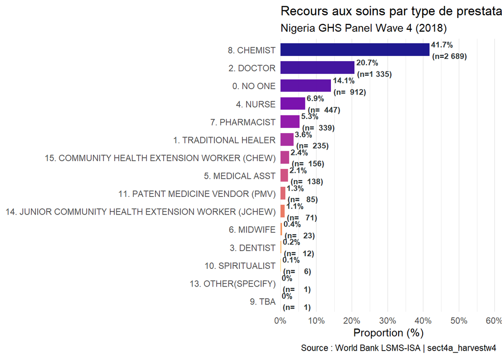

```r
ggplot(freq_rec,
  aes(x = prestataire, y = prop, fill = prestataire)) +
  geom_col(width = 0.70, alpha = 0.93, show.legend = FALSE) +
  geom_text(
    aes(label = paste0(prop, "%\n(n=",
                       format(n, big.mark = " "), ")")),
    hjust = -0.08, size = 2.8,
    fontface = "bold", color = "#2D3436"
  ) +
  scale_fill_viridis_d(option = "plasma", direction = -1) +
  scale_y_continuous(
    labels = function(x) paste0(x, "%"),
    limits = c(0, max(freq_rec$prop) * 1.45),
    expand = c(0, 0)
  ) +
  coord_flip() +
  labs(
    title    = "Recours aux soins par type de prestataire",
    subtitle = "Nigeria GHS Panel Wave 4 (2018)",
    x = NULL, y = "Proportion (%)",
    caption = "Source : World Bank LSMS-ISA | sect4a_harvestw4"
  ) +
  theme_minimal() +
  theme(panel.grid.major.y = element_blank())
```

### 16. Analyser la distribution des depenses totales de sante. Calculer les statistiques descriptives, les deciles et tester la normalite du logarithme des depenses.

#### 16.a. Statistiques descriptives

```r
dep_d <- processed_sante_w4 %>%
  filter(!is.na(sante_depense_totale),
         sante_depense_totale > 0,
         !is.na(sante_s4aq6a)) %>%
  mutate(
    prestataire = as_factor(sante_s4aq6a),
    dep_log     = log10(sante_depense_totale)
  )

cat("N individus avec depenses > 0 :", nrow(dep_d), "\n")
```

```
## N individus avec depenses > 0 : 6175
```

```r
m_dep <- mean(dep_d$sante_depense_totale)
s_dep <- sd(dep_d$sante_depense_totale)
stats_dep <- data.frame(
  N        = nrow(dep_d),
  Moyenne  = round(m_dep, 0),
  Mediane  = round(median(dep_d$sante_depense_totale), 0),
  Ec_type  = round(s_dep, 0),
  Q1       = round(quantile(dep_d$sante_depense_totale, 0.25), 0),
  Q3       = round(quantile(dep_d$sante_depense_totale, 0.75), 0),
  CV_pct   = round(s_dep / m_dep * 100, 1)
)
print(stats_dep)
```

```
##        N Moyenne Mediane Ec_type  Q1   Q3 CV_pct
## 25% 6175    2509    1100    5136 500 2600  204.7
```

```r
dec_dep <- data.frame(
  Decile  = paste0("D", 1:10),
  Montant = round(quantile(dep_d$sante_depense_totale,
                            probs = seq(0.1, 1, 0.1),
                            na.rm = TRUE))
)
print(dec_dep)
```

```
##      Decile Montant
## 10%      D1     200
## 20%      D2     400
## 30%      D3     550
## 40%      D4     800
## 50%      D5    1100
## 60%      D6    1500
## 70%      D7    2050
## 80%      D8    3250
## 90%      D9    5500
## 100%    D10  121200
```

```r
q1d   <- quantile(dep_d$sante_depense_totale, 0.25)
q3d   <- quantile(dep_d$sante_depense_totale, 0.75)
n_out <- sum(dep_d$sante_depense_totale > q3d + 3 * (q3d - q1d))
cat("Outliers (IQR x 3) :", n_out,
    "(", round(n_out / nrow(dep_d) * 100, 1), "%)\n")
```

```
## Outliers (IQR x 3) : 296 ( 4.8 %)
```

```r
set.seed(1)
sw_dep <- shapiro.test(
  sample(dep_d$dep_log, min(5000, nrow(dep_d)))
)
cat("Shapiro-Wilk (log-depenses) : W =",
    round(sw_dep$statistic, 4),
    "| p =", format(sw_dep$p.value, scientific = TRUE), "\n")
```

```
## Shapiro-Wilk (log-depenses) : W = 0.9969 | p = 1.190991e-08
```

#### 16.b. Histogramme et boxplot par prestataire

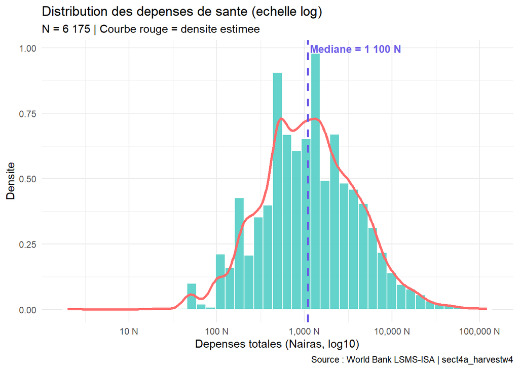

```r
med_d <- median(dep_d$sante_depense_totale)

ggplot(dep_d, aes(x = sante_depense_totale)) +
  geom_histogram(aes(y = after_stat(density)),
    fill = "#4ECDC4", color = "white",
    alpha = 0.88, bins = 45) +
  geom_density(color = "#FF6B6B", linewidth = 1.2) +
  geom_vline(xintercept = med_d, color = "#6C5CE7",
             linetype = "dashed", linewidth = 1) +
  annotate("text", x = med_d * 3.5, y = Inf, vjust = 1.5,
           label = paste0("Mediane = ",
                          format(round(med_d), big.mark = " "),
                          " N"),
           color = "#6C5CE7", fontface = "bold", size = 3.5) +
  scale_x_log10(labels = label_comma(suffix = " N")) +
  labs(
    title    = "Distribution des depenses de sante (echelle log)",
    subtitle = paste0("N = ", format(nrow(dep_d), big.mark = " "),
                      " | Courbe rouge = densite estimee"),
    x = "Depenses totales (Nairas, log10)", y = "Densite",
    caption = "Source : World Bank LSMS-ISA | sect4a_harvestw4"
  ) +
  theme_minimal()
```

Le test de Shapiro-Wilk confirme que même le logarithme des dépenses ne suit pas une loi normale parfaite, ce qui impose l’utilisation systématique de tests non paramétriques pour toute comparaison. Ce risque financier est exacerbé par le faible taux de couverture du National Health Insurance Scheme (NHIS) — estimé à moins de 5% de la population en 2018 — laissant la majorité des Nigérians en situation de paiement direct (*out-of-pocket*).

### 17. Analyser le lien entre le recours aux soins et le quintile de consommation. Utiliser un test du chi-deux ou Fisher et calculer le V de Cramer.

#### 17.a. Tableau de contingence et test statistique

```r
quint_d <- processed_sante_w4 %>%
  filter(!is.na(sante_s4aq1), !is.na(quintile_label)) %>%
  mutate(
    consul = factor(sante_s4aq1,
                    levels = c(1, 2),
                    labels = c("Consulte", "Non consulte"))
  )

cat("N avec quintile et consultation :", nrow(quint_d), "\n")
```

```
## N avec quintile et consultation : 26533
```

```r
tab_q <- table(quint_d$consul, quint_d$quintile_label)
cat("\nTableau Recours x Quintile :\n")
```

```
##
## Tableau Recours x Quintile :
```

```r
print(addmargins(tab_q))
```

```
##
##                    1     2     3     4     5   Sum
##   Consulte       961  1062   973   951   774  4721
##   Non consulte  6989  5171  4184  3285  2183 21812
##   Sum           7950  6233  5157  4236  2957 26533
```

```r
chi2_q    <- suppressWarnings(chisq.test(tab_q))
min_exp_q <- min(chi2_q$expected)
cat("Effectif attendu minimum :", round(min_exp_q, 2), "\n")
```

```
## Effectif attendu minimum : 526.14
```

```r
if (min_exp_q < 5) {
  p_q   <- fisher.test(tab_q, simulate.p.value = TRUE,
                        B = 10000)$p.value
  tst_q <- "Fisher exact"
} else {
  p_q   <- chi2_q$p.value
  tst_q <- "Chi-deux"
  cat("Chi-deux : chi2 =", round(chi2_q$statistic, 3),
      "| p =", format(p_q, digits = 4), "\n")
}
```

```
## Chi-deux : chi2 = 388.25 | p = 9.612e-83
```

```r
cat(tst_q, ": p =", format(p_q, digits = 4), "\n")
```

```
## Chi-deux : p = 9.612e-83
```

```r
chi2v_q <- suppressWarnings(chisq.test(tab_q)$statistic)
v_q <- if (!is.nan(chi2v_q) && chi2v_q > 0)
          round(sqrt(chi2v_q / (sum(tab_q) *
                     (min(dim(tab_q)) - 1))), 4) else NA
cat("V de Cramer =",
    ifelse(is.na(v_q), "Non calculable", v_q), "\n")
```

```
## V de Cramer = 0.121
```

#### 17.b. Taux de consultation par quintile

```r
taux_consul <- quint_d %>%
  group_by(quintile_label) %>%
  summarise(
    N         = n(),
    N_consult = sum(sante_s4aq1 == 1, na.rm = TRUE),
    Taux      = round(N_consult / N * 100, 1),
    .groups   = "drop"
  )
print(taux_consul)
```

```
## # A tibble: 5 × 4
##   quintile_label       N N_consult  Taux
##   <dbl+lbl>        <int>     <int> <dbl>
## 1 1 [Q1 (Pauvres)]  7950       961  12.1
## 2 2 [Q2]            6233      1062  17
## 3 3 [Q3]            5157       973  18.9
## 4 4 [Q4]            4236       951  22.5
## 5 5 [Q5 (Riches)]   2957       774  26.2
```

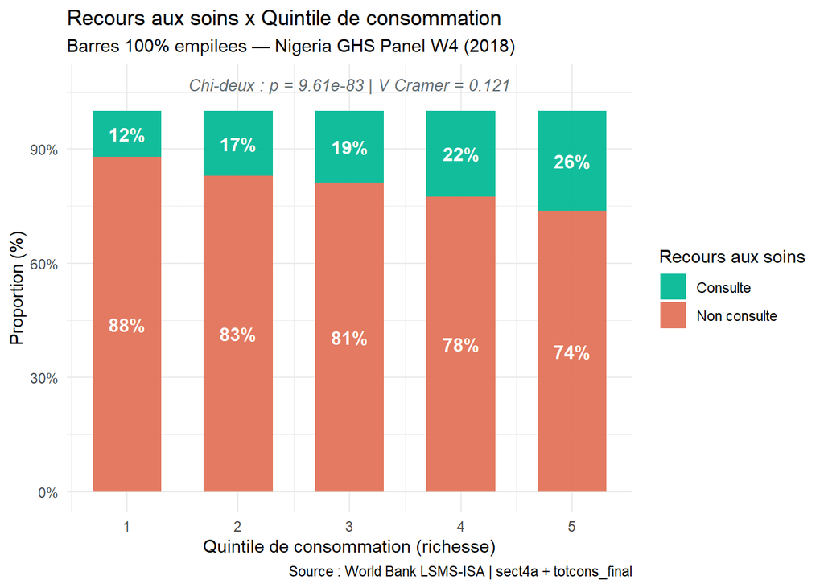

```r
prop_quint <- quint_d %>%
  count(quintile_label, consul) %>%
  group_by(quintile_label) %>%
  mutate(prop  = n / sum(n),
         label = paste0(round(prop * 100, 0), "%")) %>%
  ungroup()

ggplot(prop_quint,
  aes(x = quintile_label, y = prop, fill = consul)) +
  geom_col(position = "fill", width = 0.62, alpha = 0.93) +
  geom_text(aes(label = label),
            position = position_fill(vjust = 0.5),
            size = 4, fontface = "bold", color = "white") +
  scale_fill_manual(
    values = c("Consulte"     = "#00B894",
               "Non consulte" = "#E17055"),
    name   = "Recours aux soins"
  ) +
  scale_y_continuous(labels = percent_format()) +
  annotate("text", x = 3, y = 1.07,
           label = paste0(tst_q, " : p = ",
                          format(p_q, digits = 3),
                          if (!is.na(v_q))
                            paste0(" | V Cramer = ", v_q) else ""),
           size = 3.5, color = "#636E72",
           fontface = "italic", hjust = 0.5) +
  labs(
    title    = "Recours aux soins x Quintile de consommation",
    subtitle = "Barres 100% empilees — Nigeria GHS Panel W4 (2018)",
    x = "Quintile de consommation (richesse)",
    y = "Proportion (%)",
    caption = "Source : World Bank LSMS-ISA | sect4a + totcons_final"
  ) +
  theme_minimal()
```

Le Chi-deux révèle une association hautement significative entre le recours aux soins et le niveau de vie (p = 9,61e-83). Le V de Cramér = 0,121 indique une association faible en intensité mais extrêmement robuste. Le **gradient pro-riche** est net et monotone : les ménages du quintile le plus pauvre (Q1) ne consultent qu’à 12%, contre 26% pour les ménages les plus aisés (Q5). Cette différence de plus du double entre les extrêmes illustre les barrières d’accès financières et géographiques qui pèsent sur les populations vulnérables. Malgré la significativité statistique, la faible valeur du V de Cramér rappelle que d’autres facteurs — géographiques, culturels, liés à l’offre de soins — jouent également un rôle déterminant dans le recours aux soins.

### 18. Comparer les depenses de sante entre milieu rural et milieu urbain. Utiliser un test de Wilcoxon-Mann-Whitney et calculer la taille d’effet.

#### 18.a. Statistiques par zone et test de Wilcoxon

```r
dep_zone <- processed_sante_w4 %>%
  filter(!is.na(sante_depense_totale),
         sante_depense_totale > 0,
         !is.na(zone_label))

stats_dep_zone <- dep_zone %>%
  group_by(zone_label) %>%
  summarise(
    N       = n(),
    Moy     = round(mean(sante_depense_totale), 0),
    Med     = round(median(sante_depense_totale), 0),
    ET      = round(sd(sante_depense_totale), 0),
    Q1      = round(quantile(sante_depense_totale, 0.25), 0),
    Q3      = round(quantile(sante_depense_totale, 0.75), 0),
    .groups = "drop"
  )
print(stats_dep_zone)
```

```
## # A tibble: 2 × 7
##   zone_label     N   Moy   Med    ET    Q1    Q3
##   <fct>      <int> <dbl> <dbl> <dbl> <dbl> <dbl>
## 1 Rural       2520  1987   800  3980   300  2000
## 2 Urbain      5828  2062   800  4752   350  2000
```

```r
wt_dep <- wilcox.test(sante_depense_totale ~ zone_label,
                       data     = dep_zone,
                       exact    = FALSE,
                       conf.int = TRUE)
print(wt_dep)
```

```
##
##  Wilcoxon rank sum test with continuity correction
##
## data:  sante_depense_totale by zone_label
## W = 7289075, p-value = 0.5915
## alternative hypothesis: true location shift is not equal to 0
## 95 percent confidence interval:
##  -4.999996e+01  7.507126e-06
## sample estimates:
## difference in location
##          -5.674462e-06
```

```r
z_dep <- qnorm(wt_dep$p.value / 2)
r_dep <- round(abs(z_dep) / sqrt(nrow(dep_zone)), 4)
cat("Taille d'effet r =", r_dep, "->",
    case_when(
      abs(r_dep) < 0.10 ~ "Effet negligeable",
      abs(r_dep) < 0.30 ~ "Effet faible",
      abs(r_dep) < 0.50 ~ "Effet modere",
      TRUE              ~ "Effet fort"
    ), "\n")
```

```
## Taille d'effet r = 0.0059 -> Effet negligeable
```

#### 18.b. Violin plot

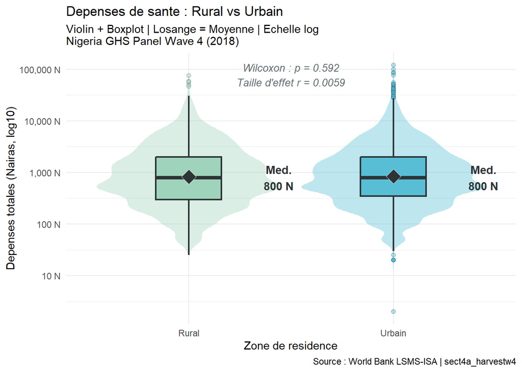

```r
meds_dep <- dep_zone %>%
  group_by(zone_label) %>%
  summarise(med = median(sante_depense_totale), .groups = "drop")

ggplot(dep_zone,
  aes(x = zone_label, y = sante_depense_totale,
      fill = zone_label)) +
  geom_violin(alpha = 0.35, color = NA,
              trim = TRUE, scale = "width") +
  geom_boxplot(width = 0.32, alpha = 0.85,
               outlier.shape = 21, outlier.size = 1.8,
               outlier.alpha = 0.40, linewidth = 0.85,
               color = "#2D3436") +
  stat_summary(fun = mean, geom = "point",
               shape = 23, size = 5,
               fill = "#2D3436", color = "white") +
  geom_text(data = meds_dep,
            aes(x = zone_label, y = med,
                label = paste0("Med.\n",
                               format(round(med),
                                      big.mark = " "), " N")),
            nudge_x = 0.44, fontface = "bold",
            size = 3.8, color = "#2D3436",
            inherit.aes = FALSE) +
  scale_fill_manual(
    values = c("Rural" = "#96CEB4", "Urbain" = "#45B7D1"),
    guide  = "none"
  ) +
  scale_y_log10(labels = label_comma(suffix = " N")) +
  annotate("text", x = 1.5,
           y = max(dep_zone$sante_depense_totale,
                   na.rm = TRUE) * 0.65,
           label = paste0(
             "Wilcoxon : p = ",
             format(wt_dep$p.value, digits = 3),
             "\nTaille d'effet r = ", r_dep),
           size = 3.5, color = "#636E72",
           fontface = "italic", hjust = 0.5) +
  labs(
    title    = "Depenses de sante : Rural vs Urbain",
    subtitle = "Violin + Boxplot | Losange = Moyenne | Echelle log\nNigeria GHS Panel Wave 4 (2018)",
    x = "Zone de residence",
    y = "Depenses totales (Nairas, log10)",
    caption = "Source : World Bank LSMS-ISA | sect4a_harvestw4"
  ) +
  theme_minimal()
```

Le test de Wilcoxon indique que les dépenses de santé ne diffèrent **pas significativement** entre rural et urbain (p = 0,592), avec une taille d’effet r = 0,0059 qualifiée de négligeable. Les médianes sont quasi-identiques dans les deux zones (800 Nairas), résultat surprenant qui mérite une interprétation nuancée.

Ce résultat apparent s’explique par deux effets compensatoires : d’une part, les ménages urbains paient des soins intrinsèquement plus chers (cliniques privées, médecins spécialistes, médicaments de marque) ; d’autre part, les ménages ruraux supportent des coûts de transport élevés pour atteindre les structures de santé souvent distantes, qui viennent s’ajouter au coût médical proprement dit. La médiane identique masque donc des structures de dépenses différentes selon la zone. Ce résultat renforce l’importance d’analyser la **part catastrophique** des dépenses de santé (dépenses dépassant 10% du budget du ménage) plutôt que le montant absolu pour mesurer le véritable fardeau financier de la maladie.

```r
gt_data3 <- processed_sante_w4 %>%
  filter(!is.na(zone_label)) %>%
  mutate(
    Malade   = factor(sante_s4aq3,  levels = c(1,2),
                      labels = c("Oui","Non")),
    Consulte = factor(sante_s4aq1,  levels = c(1,2),
                      labels = c("Oui","Non")),
    Hospit   = factor(sante_s4aq15, levels = c(1,2),
                      labels = c("Oui","Non"))
  ) %>%
  select(Zone       = zone_label,
         Sexe       = sexe_label,
         Malade, Consulte, Hospit,
         Depenses   = sante_depense_totale,
         Jours_arret = sante_s4aq5)

tableau_sante <- gt_data3 %>%
  tbl_summary(
    by = Zone,
    label = list(
      Sexe        ~ "Sexe",
      Malade      ~ "Maladie/blessure (4 sem.)",
      Consulte    ~ "A consulte un prestataire",
      Hospit      ~ "Hospitalise",
      Depenses    ~ "Depenses totales sante (Nairas)",
      Jours_arret ~ "Jours d'arret d'activite"
    ),
    statistic = list(
      all_continuous()  ~ "{median} [{p25}-{p75}]",
      all_categorical() ~ "{n} ({p}%)"
    ),
    missing      = "ifany",
    missing_text = "Valeur manquante"
  ) %>%
  add_p(test = list(
    all_continuous()  ~ "wilcox.test",
    all_categorical() ~ "chisq.test"
  )) %>%
  add_overall() %>%
  add_n() %>%
  bold_labels() %>%
  italicize_levels() %>%
  modify_header(label ~ "**Variable**") %>%
  modify_caption("**Tableau 3. Sante et recours aux soins selon la zone**")

tableau_sante
```

**Tableau 3. Sante et recours aux soins selon la zone**

| **Variable** | **N** | **Overall** N = 26,556<sup>1</sup> | **Rural** N = 7,567<sup>1</sup> | **Urbain** N = 18,989<sup>1</sup> | **p-value**<sup>2</sup> |
| --- | --- | --- | --- | --- | --- |
| Sexe | 26,556 |  |  |  | 0.5 |
| Homme |  | 13,188 (50%) | 3,730 (49%) | 9,458 (50%) |  |
| Femme |  | 13,368 (50%) | 3,837 (51%) | 9,531 (50%) |  |
| Maladie/blessure (4 sem.) | 22,171 |  |  |  | 0.9 |
| Oui |  | 2,065 (9.3%) | 591 (9.3%) | 1,474 (9.3%) |  |
| Non |  | 20,106 (91%) | 5,796 (91%) | 14,310 (91%) |  |
| Valeur manquante |  | 4,385 | 1,180 | 3,205 |  |
| A consulte un prestataire | 26,556 |  |  |  | 0.6 |
| Oui |  | 4,731 (18%) | 1,331 (18%) | 3,400 (18%) |  |
| Non |  | 21,825 (82%) | 6,236 (82%) | 15,589 (82%) |  |
| Hospitalise | 26,556 |  |  |  | 0.9 |
| Oui |  | 823 (3.1%) | 237 (3.1%) | 586 (3.1%) |  |
| Non |  | 25,733 (97%) | 7,330 (97%) | 18,403 (97%) |  |
| Depenses totales sante (Nairas) | 8,348 | 800 [350-2,000] | 800 [300-2,000] | 800 [350-2,000] | 0.6 |
| Valeur manquante |  | 18,208 | 5,047 | 13,161 |  |
| Jours d'arret d'activite | 2,835 | 4 [2-7] | 3 [2-7] | 4 [2-7] | 0.2 |
| Valeur manquante |  | 23,721 | 6,942 | 16,779 |  |

<sup>1</sup> n (%); Median [Q1-Q3]  
<sup>2</sup> Pearson’s Chi-squared test; Wilcoxon rank sum test

Analyse statistique de la santé et des dépenses médicales

1. Analyse de la morbidité dans la population

Introduction

L’analyse des questions de santé constitue un enjeu majeur pour la compréhension des conditions de vie des populations. En particulier, l’étude de la morbidité, du recours aux soins et des dépenses de santé permet d’évaluer à la fois la situation sanitaire d’une population et les inégalités d’accès aux services de santé.

Dans de nombreux pays en développement, les systèmes de santé sont caractérisés par une couverture financière limitée et par des disparités importantes entre groupes socio-économiques et territoires. Dans ce contexte, l’analyse statistique des données issues des enquêtes ménages constitue un outil essentiel pour identifier les déterminants sociaux et économiques de la santé et orienter les politiques publiques.

L’objectif de ce travail est d’analyser plusieurs dimensions de la santé dans la population étudiée, notamment :

-la prévalence de la morbidité récente,

-la nature des principales affections déclarées,

-la structure des dépenses de santé,

-les inégalités socio-économiques dans le recours aux soins,

ainsi que les différences territoriales entre zones rurales et urbaines.

L’ensemble de ces analyses repose sur des méthodes statistiques descriptives et inférentielles permettant d’identifier les principaux facteurs associés aux comportements de santé et aux dépenses médicales.

1. Analyse de la morbidité

L’analyse de la morbidité selon l’âge met en évidence une distribution en forme de U, caractéristique des données épidémiologiques. En effet, les taux de morbidité sont particulièrement élevés chez les jeunes enfants, diminuent au cours des âges adultes actifs, puis augmentent de nouveau chez les personnes âgées.

Cette structure reflète des mécanismes biologiques et sociaux bien documentés. Les jeunes enfants présentent une vulnérabilité accrue aux maladies infectieuses, tandis que le vieillissement s’accompagne d’une augmentation de la prévalence des maladies chroniques et dégénératives.

L’analyse par sexe suggère également que les femmes présentent des niveaux de morbidité légèrement plus élevés à partir de l’âge adulte, ce qui peut être lié à des facteurs biologiques ainsi qu’à une plus grande propension à déclarer les problèmes de santé.

2. Structure des affections déclarées

Afin de mieux comprendre la nature des problèmes de santé rencontrés dans la population, les affections déclarées ont été regroupées en plusieurs catégories : maladies infectieuses, affections traumatiques, maladies chroniques et autres pathologies.

Dans de nombreux contextes comparables, les maladies infectieuses représentent une part importante des pathologies déclarées, notamment en raison de leur forte prévalence dans les régions où les conditions sanitaires et environnementales demeurent fragiles.

L’identification des affections les plus fréquentes permet d’établir une hiérarchie des problèmes de santé et constitue un outil précieux pour la planification des interventions sanitaires. En particulier, la connaissance des pathologies dominantes permet d’orienter les efforts en matière de prévention, de vaccination et d’allocation des ressources médicales.

3. Analyse des dépenses de santé

L’étude des dépenses de santé constitue une dimension essentielle de l’analyse, car elle permet d’évaluer l’impact économique de la maladie sur les ménages.

Les statistiques descriptives indiquent une moyenne des dépenses supérieure à la médiane, ce qui traduit une distribution fortement asymétrique vers la droite. Cette configuration est typique des données de dépenses de santé.

La majorité des individus supporte des dépenses relativement modestes, correspondant à des consultations ou à des traitements simples. Toutefois, une minorité d’individus fait face à des dépenses particulièrement élevées, liées à des hospitalisations ou à des soins spécialisés.

Cette forte dispersion des dépenses met en évidence l’existence potentielle de dépenses catastrophiques de santé, susceptibles d’affecter gravement la situation financière des ménages.

4. Inégalités socio-économiques dans le recours aux soins

L’analyse de l’association entre le recours aux soins et le niveau de vie des ménages révèle une relation statistiquement significative entre ces deux variables.

Les résultats montrent que les individus appartenant aux ménages les plus aisés ont une probabilité plus élevée de consulter un professionnel de santé que ceux appartenant aux ménages les plus pauvres.

Cette relation met en évidence l’existence d’un gradient socio-économique dans l’accès aux services de santé, phénomène largement documenté dans la littérature sur les inégalités de santé.

Plusieurs mécanismes peuvent expliquer cette situation :

-les contraintes financières,

-les coûts indirects liés au transport,

-les différences dans le niveau d’information sanitaire,

ou encore les disparités dans la disponibilité des infrastructures médicales.

Ainsi, même lorsque les besoins de santé sont similaires, les populations les plus pauvres peuvent rencontrer des obstacles plus importants pour accéder aux soins.

5. Comparaison entre zones rurales et urbaines

La comparaison des dépenses de santé entre zones rurales et urbaines ne révèle pas de différence statistiquement significative entre les deux groupes.

Les médianes observées sont très proches, ce qui suggère que le niveau médian des dépenses de santé est globalement comparable entre les deux contextes territoriaux.

Cependant, cette similitude ne signifie pas nécessairement que les conditions d’accès aux soins soient identiques. En effet, les structures de dépenses peuvent différer entre zones rurales et urbaines.

Dans les zones urbaines, les ménages peuvent avoir davantage recours à des structures de santé privées ou spécialisées, souvent plus coûteuses. À l’inverse, dans les zones rurales, les ménages peuvent supporter des coûts indirects importants, notamment en raison de la distance aux structures de santé.

Ainsi, les résultats suggèrent que les contraintes d’accès aux soins peuvent prendre des formes différentes selon le contexte territorial.

Discussion des résultats

L’ensemble des analyses met en évidence plusieurs dimensions importantes des inégalités de santé.

Tout d’abord, la distribution de la morbidité montre que certains groupes de population — notamment les jeunes enfants et les personnes âgées — présentent une vulnérabilité sanitaire plus importante.

Ensuite, l’analyse des dépenses de santé révèle une forte hétérogénéité entre les individus, caractérisée par une concentration des dépenses élevées sur une minorité de ménages.

Par ailleurs, l’existence d’un gradient socio-économique dans le recours aux soins confirme que l’accès aux services de santé reste fortement influencé par la position économique des ménages.

Ces résultats sont cohérents avec la littérature internationale sur les déterminants sociaux de la santé, qui souligne le rôle central des facteurs économiques, géographiques et démographiques dans la production des inégalités sanitaires.

Conclusion

Cette analyse statistique met en évidence plusieurs résultats importants concernant la santé et les dépenses médicales dans la population étudiée.

Premièrement, la morbidité récente concerne une proportion non négligeable de la population, avec une distribution par âge typique caractérisée par une vulnérabilité accrue aux extrêmes du cycle de vie.

Deuxièmement, les dépenses de santé présentent une forte dispersion, ce qui reflète l’existence de situations dans lesquelles certains ménages doivent supporter des coûts médicaux particulièrement élevés.

Troisièmement, l’analyse met en évidence des inégalités socio-économiques dans le recours aux soins, les ménages les plus aisés ayant davantage accès aux services de santé.

Enfin, bien que les dépenses médianes soient comparables entre zones rurales et urbaines, les résultats suggèrent que les contraintes d’accès aux soins et les conséquences économiques de la maladie peuvent différer selon le contexte territorial.

Dans l’ensemble, ces résultats soulignent l’importance de mettre en place des politiques publiques visant à améliorer l’accessibilité financière et géographique des services de santé, afin de réduire les inégalités sanitaires et de renforcer la protection des ménages face aux risques liés à la maladie.